# CSDE 502 Winter 2021, Assignment 10

Lizzy Pelletier

2021-03-17 19:21

# 1 Introduction

In this paper, I study death rates for U.S. birth cohorts that are likely to have experienced increased mortality at young ages due to World War II. The U.S. had more than 400,000 military deaths in the war. I aim to determine which birth cohorts were most affected by wartime mortality, and see to what extent war deaths show up in male mortality rates among birth cohorts that are likely to have served.

# 2 Methods

## 2.1 Data

I use data from the [Human Mortality Database](https://www.mortality.org/). This database was created by a multi-institution collaboration of researchers and contains detailed demographic information for 41 countries. Specifically, I downloaded the cohort death rates (with age intervals of 1, over 1 year) for the U.S.

```r
m <- read.table("cMx_1x1.txt", skip=2, header=TRUE)
```

## 2.2 Analysis

I examine male mortality rates starting with the 1918 birth cohort, which is the first cohort that can be tracked in the data starting at age 15. I follow 20 years of birth cohorts, ending with the 1938 cohort, who would have been 7 when the war ended and almost certainly not affected in terms of mortality. I follow these cohorts from age 15 through age 45 and plot mortality rates below.

```r
m.analytic <- m %>%
  filter(Year>=1918 & Year <=1938) %>%
  select(Year, Age, Male)
```

# 3 Results

Below is a table of mortality rates at key ages (18-22) for these cohorts:

```r
t1 <- m.analytic %>%
  mutate(Age=as.numeric(as.character(Age))) %>%
  filter(Age>=18 & Age<=22) %>%
  pivot_wider(id_cols=Year, values_from=Male, names_from = Age)
names(t1) <- c("Birth Year", "18", "19", "20", "21", "22")
kable(t1)
```

| Birth Year | 18 | 19 | 20 | 21 | 22 |
| --- | --- | --- | --- | --- | --- |
| 1918 | 0.002835 | 0.002768 | 0.002614 | 0.002643 | 0.002758 |
| 1919 | 0.002564 | 0.002451 | 0.002488 | 0.002622 | 0.002799 |
| 1920 | 0.002271 | 0.002317 | 0.002465 | 0.002659 | 0.003140 |
| 1921 | 0.002135 | 0.002292 | 0.002480 | 0.002986 | 0.003634 |
| 1922 | 0.002107 | 0.002286 | 0.002779 | 0.003579 | 0.003855 |
| 1923 | 0.002087 | 0.002528 | 0.003452 | 0.003936 | 0.003033 |
| 1924 | 0.002211 | 0.003099 | 0.003876 | 0.003061 | 0.002415 |
| 1925 | 0.002505 | 0.003455 | 0.003013 | 0.002406 | 0.002254 |
| 1926 | 0.002658 | 0.002876 | 0.002357 | 0.002220 | 0.002113 |
| 1927 | 0.002527 | 0.002251 | 0.002134 | 0.002063 | 0.001997 |
| 1928 | 0.002157 | 0.001976 | 0.001971 | 0.001941 | 0.002053 |
| 1929 | 0.001835 | 0.001821 | 0.001860 | 0.001948 | 0.002147 |
| 1930 | 0.001673 | 0.001722 | 0.001854 | 0.002013 | 0.002162 |
| 1931 | 0.001609 | 0.001736 | 0.001953 | 0.002093 | 0.002121 |
| 1932 | 0.001632 | 0.001850 | 0.002056 | 0.002097 | 0.002094 |
| 1933 | 0.001716 | 0.001889 | 0.002001 | 0.002041 | 0.002121 |
| 1934 | 0.001713 | 0.001783 | 0.001923 | 0.002042 | 0.002066 |
| 1935 | 0.001581 | 0.001720 | 0.001915 | 0.001974 | 0.001935 |
| 1936 | 0.001577 | 0.001792 | 0.001933 | 0.001925 | 0.001935 |
| 1937 | 0.001606 | 0.001799 | 0.001858 | 0.001946 | 0.001860 |
| 1938 | 0.001631 | 0.001748 | 0.001827 | 0.001920 | 0.001789 |

It seems as though mortality at these ages is elevated for the 1918-1927 birth cohorts, then drops off.

Next, I look at the data another way: looking at mortality in these cohorts by calendar year.

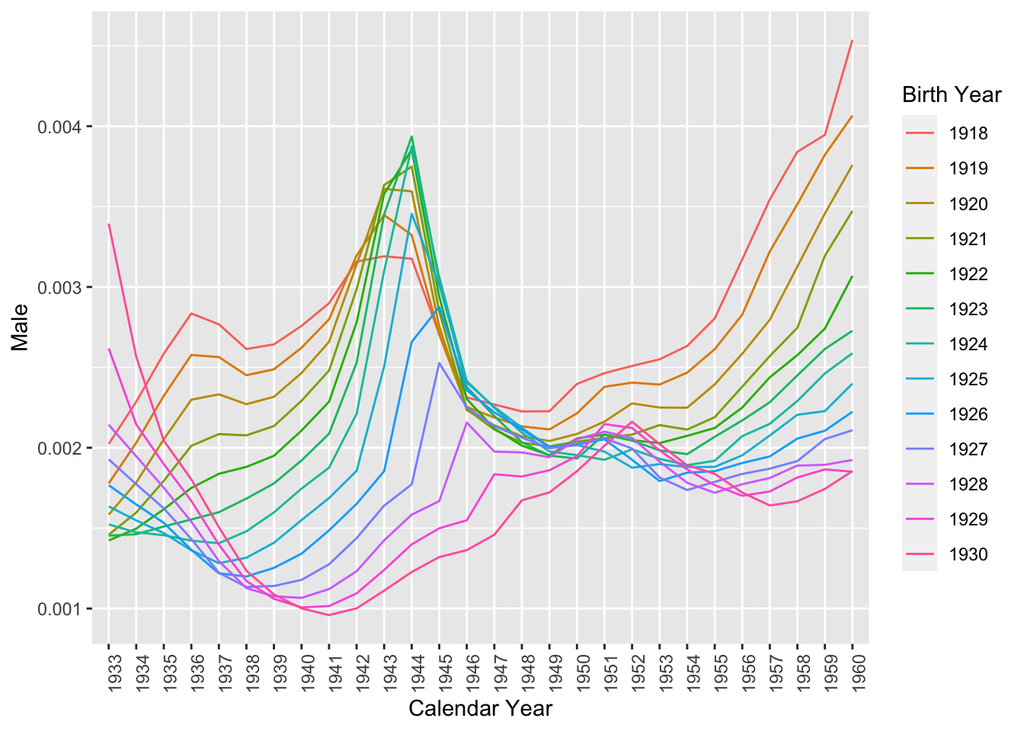

```r
m.plot <- m.analytic %>%
  mutate(Year = as.numeric(as.character(Year))) %>%
  mutate(Age = as.numeric(as.character(Age))) %>%
  mutate(calyr = Year + Age) %>%
  filter(calyr >= 1933 & calyr <= 1960) %>%
  mutate(calyr = factor(calyr, ordered=TRUE)) %>%
  filter(Year<1931) %>%
  mutate(Male = as.numeric(as.character(Male)))
ggplot(m.plot, aes(x=calyr, y=Male, group=as.factor(Year))) +
  geom_line(aes(color=as.factor(Year))) +
  xlab("Calendar Year") +
  scale_color_discrete(name="Birth Year") +
  theme(axis.text.x=element_text(angle=90))
```

# 4 Discussion and Conclusions

The war appears to visibly increase mortality rates for the 1918-1928 birth cohorts. However, many of the patterns appear to be due to age. For example, the high rate of mortality among the 1930 birth cohort in 1933 likely reflects higher child mortality, and the rising mortality among the 1918 cohort starting in 1950 likely reflects increased age. A more sophisticated analysis would disentangle these effects more formally.